# Unit2Project

2026-02-03

#HomeWork ## Unit Project 02 - L06: ggplot2

```r
penguins <- penguins %>%
  drop_na(flipper_length_mm, body_mass_g, bill_length_mm, bill_depth_mm, sex)
```

## Q1

There is a little difference in the background, for example the shade.

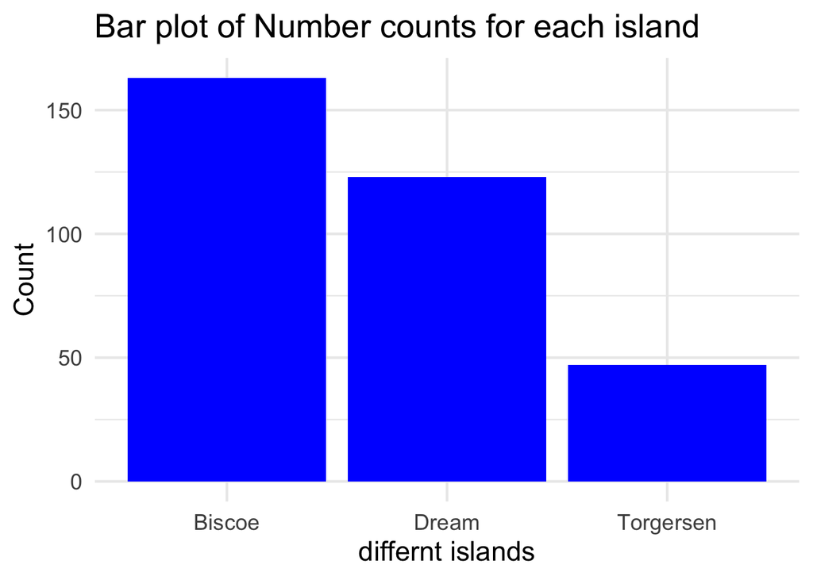

```r
# Q1
ggplot(data = penguins, aes(x = island)) +
  geom_bar(fill = "blue") +
  labs(title = "Bar plot of Number counts for each island", x = "differnt islands", y = "Count") +
  theme_minimal(base_size = 17)
```

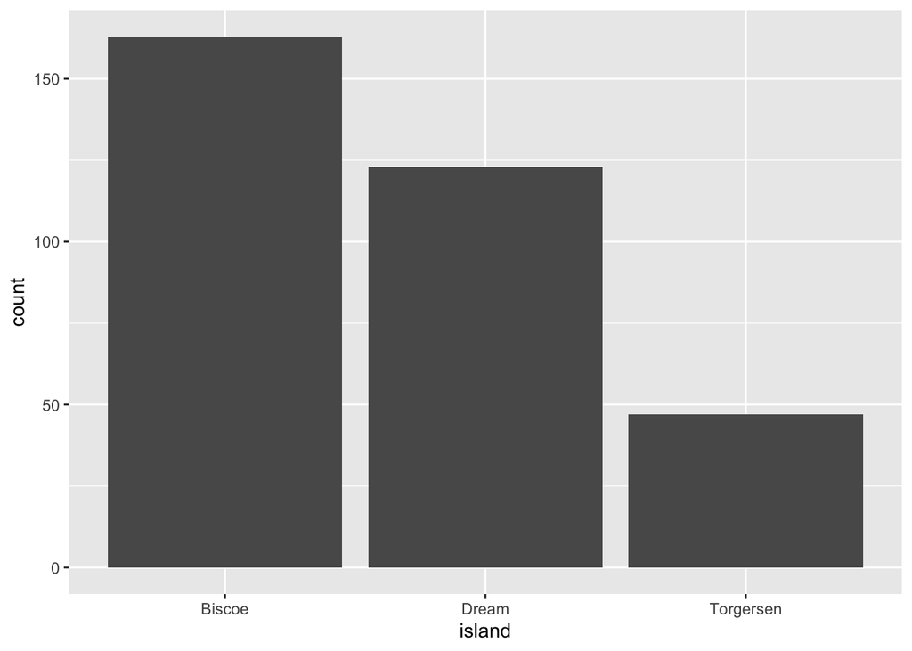

```r
# here do not need to assign y axis because ggplot automatically counts observations and scales the y-axis based on the maximum count in the data.

ggplot(data = penguins, aes(x = island)) +
  geom_bar() +
  labs()
```

## Q2

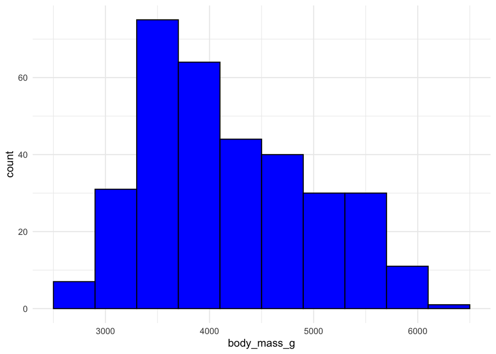

```r
ggplot(data = penguins, aes(x = body_mass_g)) +
  geom_histogram(bins = 10,
                 fill = "blue",
                 color = "black") +
  theme_minimal()
```

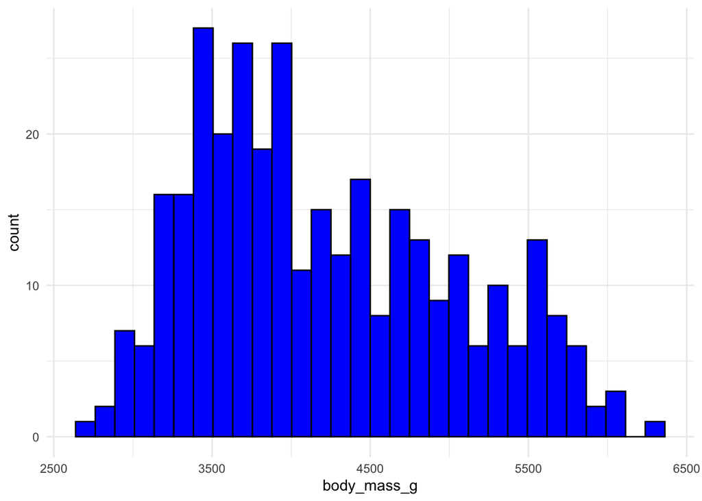

```r
ggplot(data = penguins, aes(x = body_mass_g)) +
  geom_histogram(bins = 30,
                 fill = "blue",
                 color = "black") +
  theme_minimal()
```

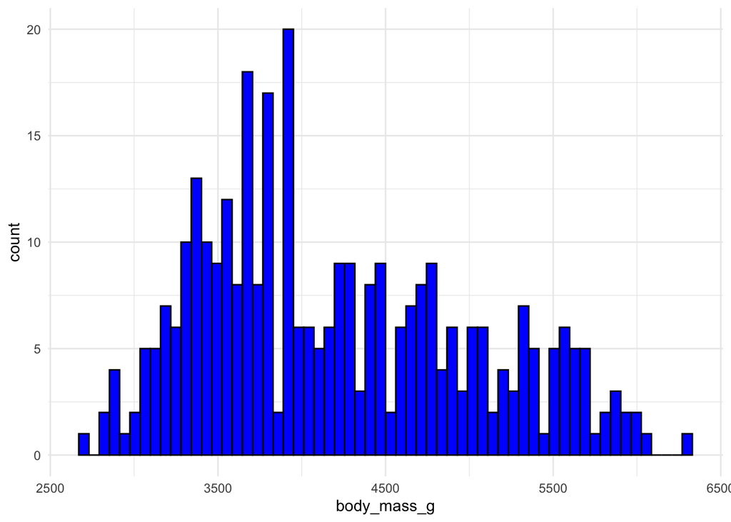

```r
ggplot(data = penguins, aes(x = body_mass_g)) +
  geom_histogram(bins = 60,
                 fill = "blue",
                 color = "black") +
  theme_minimal()
```

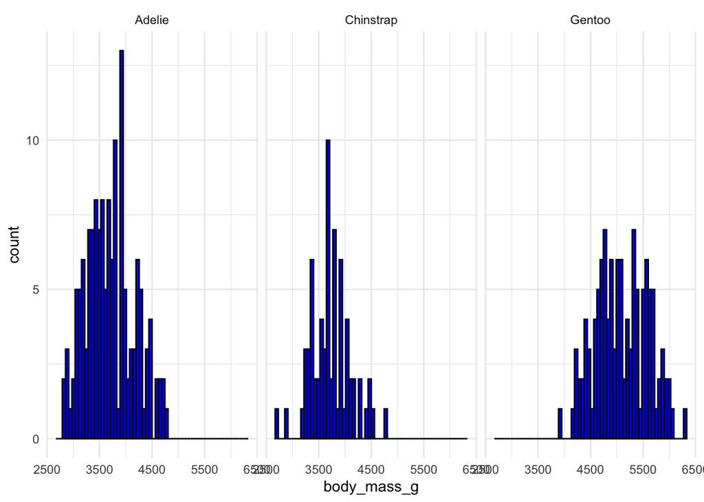

```r
##


ggplot(data = penguins, aes(x = body_mass_g)) +
  geom_histogram(bins = 60,
                 fill = "blue",
                 color = "black") +
  facet_wrap(~ species) +
  theme_minimal()
```

## Q3

The body mass of Gentoo is much higher than Adelie and Chinstrap, for the body_mass_g, male and females differ. After adding fill, the readability increased.

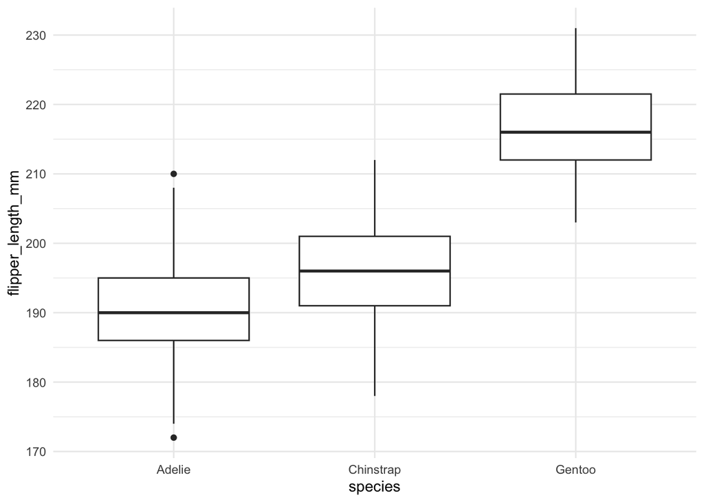

```r
ggplot(data = penguins,
       aes(x = species, y = flipper_length_mm)) +
  geom_boxplot() +
  theme_minimal()
```

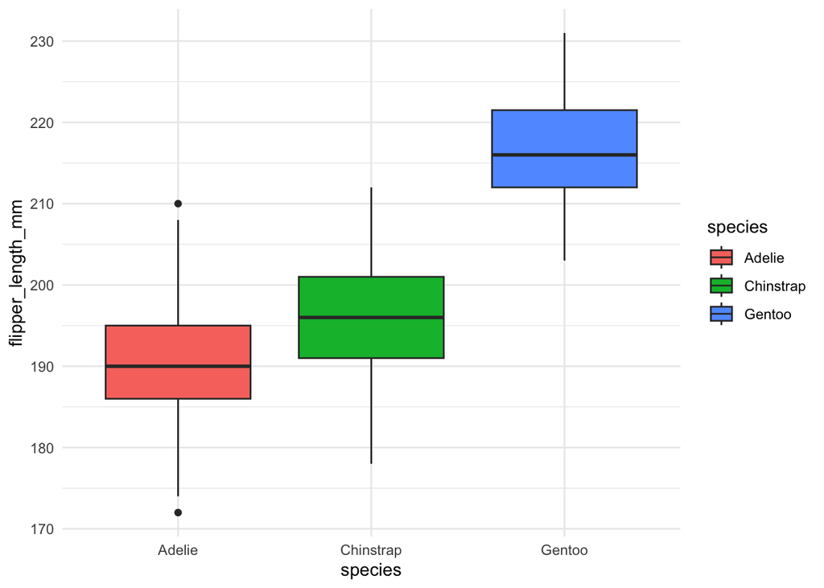

```r
ggplot(data = penguins,
       aes(x = species, y = flipper_length_mm, fill = species)) +
  geom_boxplot() +
  theme_minimal()
```

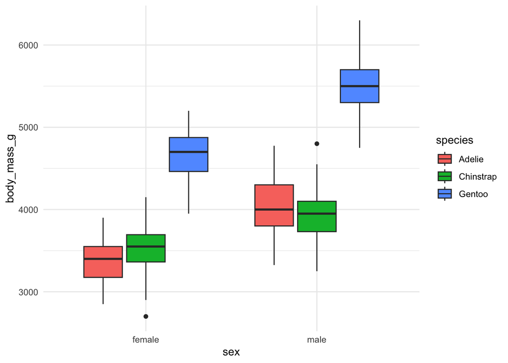

```r
ggplot(data = penguins,
       aes(x = sex, y = body_mass_g, fill = species)) +
  geom_boxplot() +
  theme_minimal()
```

## Q4

The relationship is hard to tell if not using the geom_smooth, but if using it, we can see all the relationship is positive. By adding color to the chart, it makes different species more recognizable Yes, the line fit the data well, it is showing the trend.

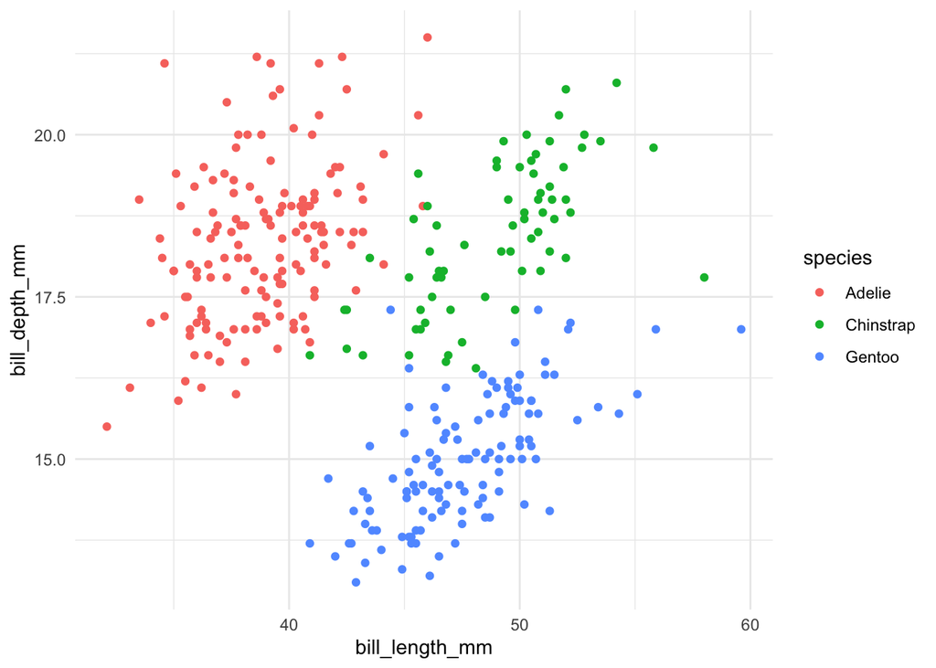

```r
ggplot(penguins,
       aes(x = bill_length_mm, y = bill_depth_mm, color = species)) +
  geom_point()  +
  theme_minimal()
```

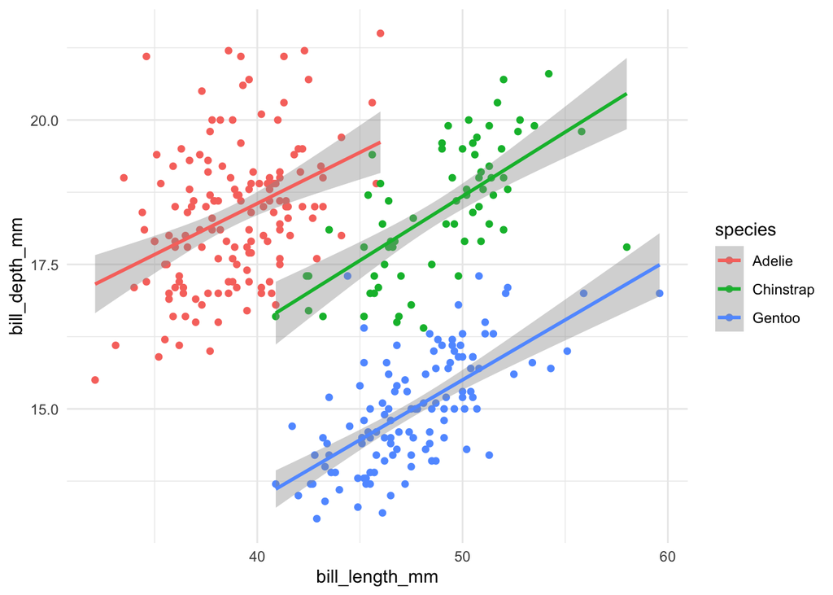

```r
# No geom_scatter, only geom_point

ggplot(penguins,
       aes(x = bill_length_mm, y = bill_depth_mm, color = species)) +
  geom_point()  +
  geom_smooth(method = "lm") +
  theme_minimal()
```

## Q5

Genoo shows strongest relationship, with flipper length increase, body mass increase facet_grid(sex ~ species) making graph showing in distinct small graph, which is much clear to see the difference.

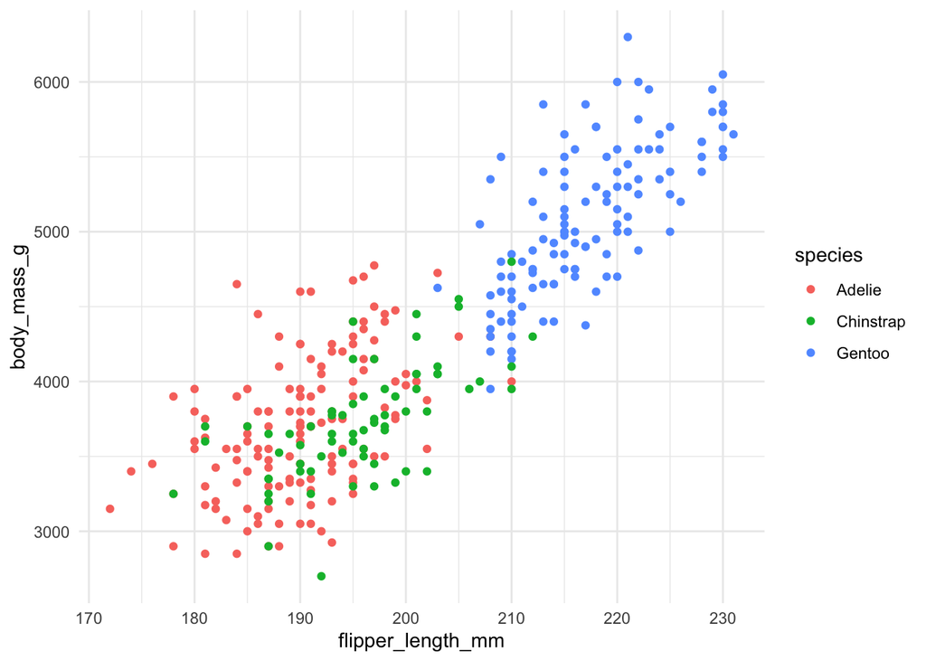

```r
ggplot(penguins, aes(x = flipper_length_mm, y = body_mass_g, color = species)) +
  geom_point() +
  theme_minimal()
```

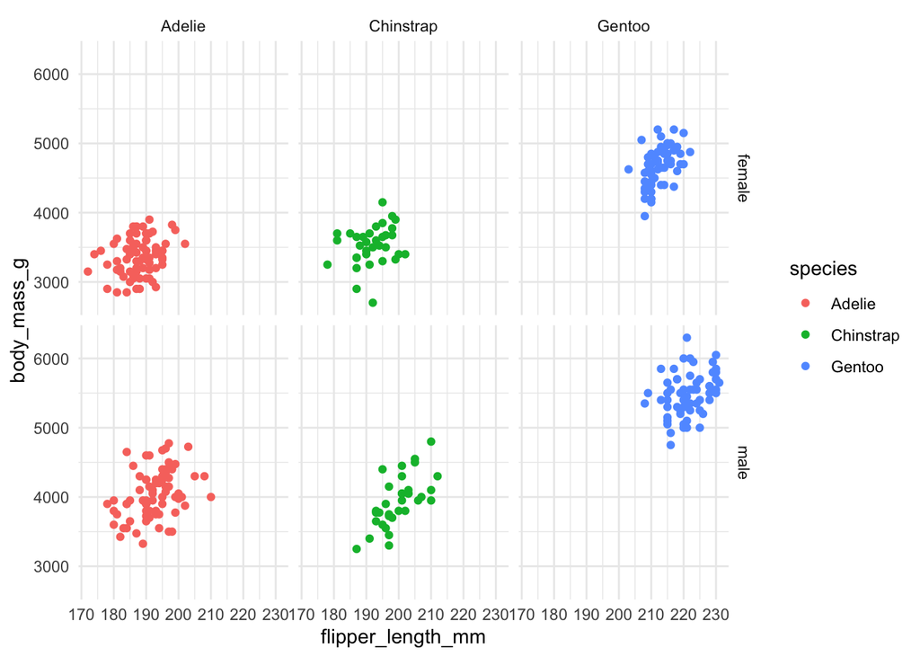

```r
ggplot(penguins, aes(x = flipper_length_mm, y = body_mass_g, color = species)) +
  geom_point() +
  facet_grid(sex~species) +
  theme_minimal()
```

## Q6

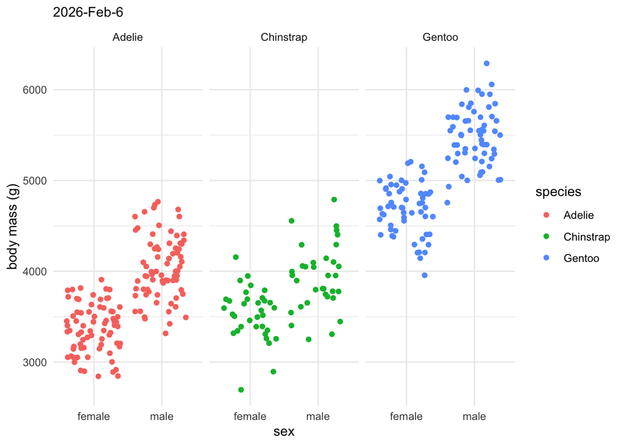

```r
ggplot(penguins, aes(x = sex, y = body_mass_g, color = species)) +
  geom_jitter() +
  facet_wrap(~species) +
  labs(y = "body mass (g)", subtitle = "2026-Feb-6") +
  theme_minimal()
```

## Q7

Draw the diagram is really interesting and how different command can lead to different graphs. easy and strait forward command, really concise and easy to use. Difficulty thing is when typo happens to the functions, sometimes really hard to quickly discover wrote it wrong.

## Lec 7

## Unit Project 02 - L07: Regular Expressions

## Regular Expressions (Regex)

Regex metacharacter `^$*+?()[]{}|\`

Rule 1

```r
x <- c("cat", "caterpillar", "dog")
str_detect(x, "cat")
```

```
## [1]  TRUE  TRUE FALSE
```

Rule 2: Ranges square brackets define set/ranges of characters

`[A-Z]` any uppercase letter `[a-z]` any lowercase letter `[0-9]` any number

```r
x <- c("Abandon","Abstract", "Advice", "advice")
str_detect(x, "[A-Z]")
```

```
## [1]  TRUE  TRUE  TRUE FALSE
```

Rule 3: Anchors `^` matches the START of a string

```r
x <- c("Absolute", "basement")
str_detect(x, "^a")
```

```
## [1] FALSE FALSE
```

Rule 4: wildcards matches any one character `.` matches any one character

Example

```r
x <- c("Absolute", "basement")
str_detect(x, ".a")
```

```
## [1] FALSE  TRUE
```

Rule 7: Quantifiers `?` 0 or 1 `*` 0 or more `+` 1 or more `{m}` exactly m times

Examples

```r
x <- c("ct", "cat", "caat", "caaat", "cart", "ate", "cave", "caave")
str_detect(x, "ca?t")
```

```
## [1]  TRUE  TRUE FALSE FALSE FALSE FALSE FALSE FALSE
```

```r
str_detect(x, "ca*t")
```

```
## [1]  TRUE  TRUE  TRUE  TRUE FALSE FALSE FALSE FALSE
```

```r
str_detect(x, "ca+t")
```

```
## [1] FALSE  TRUE  TRUE  TRUE FALSE FALSE FALSE FALSE
```

```r
str_detect(x, "ca{2}t")
```

```
## [1] FALSE FALSE  TRUE FALSE FALSE FALSE FALSE FALSE
```

```r
str_detect(x, "a.*t")
```

```
## [1] FALSE  TRUE  TRUE  TRUE  TRUE  TRUE FALSE FALSE
```

```r
str_detect(x, "ca.*t")
```

```
## [1] FALSE  TRUE  TRUE  TRUE  TRUE FALSE FALSE FALSE
```

```r
str_detect(x, "ca*t")
```

```
## [1]  TRUE  TRUE  TRUE  TRUE FALSE FALSE FALSE FALSE
```

Rule 8: Escaping to literally match a metacharacter in a string add a leading “\”

Example

```r
x <- c("Study.csv", "Work.csv", "123..csv")
str_detect(x, "S*.csv")
```

```
## [1] TRUE TRUE TRUE
```

```r
str_detect(x, "S*.\\.csv")
```

```
## [1] TRUE TRUE TRUE
```

```r
str_detect(x, "S*.\\.csv$")
```

```
## [1] TRUE TRUE TRUE
```

Rule 9: Shorthands `\\d` digits (0, 9) `\\s` whitespace (spaces, tabs) `\\w` words [A-Z, a-z, 0-9, _ ] `\\b` word boundaries

Examples

```r
x <- c("cat", "a cat", "cat!", "scatter")


# For `\\w`
str_detect(x, "\\w")
```

```
## [1] TRUE TRUE TRUE TRUE
```

```r
str_detect(x, "\\w+")
```

```
## [1] TRUE TRUE TRUE TRUE
```

```r
str_detect(x, "\\w+$")
```

```
## [1]  TRUE  TRUE FALSE  TRUE
```

```r
str_detect(x, "^\\w+$")
```

```
## [1]  TRUE FALSE FALSE  TRUE
```

```r
#For `\\b` word boundaries
str_detect(x, "\\bcat\\b")
```

```
## [1]  TRUE  TRUE  TRUE FALSE
```

`str_replace()` `str_replace_all()`

# Exercise

```r
penguins_messy <- read.csv("penguins_messy.csv")


# Q1
str_detect(penguins_messy$species_messy, "adelie")
```

```
##   [1]  TRUE  TRUE  TRUE  TRUE  TRUE  TRUE  TRUE  TRUE  TRUE  TRUE  TRUE  TRUE
##  [13]  TRUE  TRUE  TRUE  TRUE  TRUE  TRUE  TRUE  TRUE  TRUE  TRUE  TRUE  TRUE
##  [25]  TRUE  TRUE  TRUE  TRUE  TRUE  TRUE  TRUE  TRUE  TRUE  TRUE  TRUE  TRUE
##  [37]  TRUE  TRUE  TRUE  TRUE  TRUE  TRUE  TRUE  TRUE  TRUE  TRUE  TRUE  TRUE
##  [49]  TRUE  TRUE  TRUE  TRUE  TRUE  TRUE  TRUE  TRUE  TRUE  TRUE  TRUE  TRUE
##  [61]  TRUE  TRUE  TRUE  TRUE  TRUE  TRUE  TRUE  TRUE  TRUE  TRUE  TRUE  TRUE
##  [73]  TRUE  TRUE  TRUE  TRUE  TRUE  TRUE  TRUE  TRUE  TRUE  TRUE  TRUE  TRUE
##  [85]  TRUE  TRUE  TRUE  TRUE  TRUE  TRUE  TRUE  TRUE  TRUE  TRUE  TRUE  TRUE
##  [97]  TRUE  TRUE  TRUE  TRUE  TRUE  TRUE  TRUE  TRUE  TRUE  TRUE  TRUE  TRUE
## [109]  TRUE  TRUE  TRUE  TRUE  TRUE  TRUE  TRUE  TRUE  TRUE  TRUE  TRUE  TRUE
## [121]  TRUE  TRUE  TRUE  TRUE  TRUE  TRUE  TRUE  TRUE  TRUE  TRUE  TRUE  TRUE
## [133]  TRUE  TRUE  TRUE  TRUE  TRUE  TRUE  TRUE  TRUE  TRUE  TRUE  TRUE  TRUE
## [145]  TRUE  TRUE  TRUE  TRUE  TRUE  TRUE  TRUE  TRUE FALSE FALSE FALSE FALSE
## [157] FALSE FALSE FALSE FALSE FALSE FALSE FALSE FALSE FALSE FALSE FALSE FALSE
## [169] FALSE FALSE FALSE FALSE FALSE FALSE FALSE FALSE FALSE FALSE FALSE FALSE
## [181] FALSE FALSE FALSE FALSE FALSE FALSE FALSE FALSE FALSE FALSE FALSE FALSE
## [193] FALSE FALSE FALSE FALSE FALSE FALSE FALSE FALSE FALSE FALSE FALSE FALSE
## [205] FALSE FALSE FALSE FALSE FALSE FALSE FALSE FALSE FALSE FALSE FALSE FALSE
## [217] FALSE FALSE FALSE FALSE FALSE FALSE FALSE FALSE FALSE FALSE FALSE FALSE
## [229] FALSE FALSE FALSE FALSE FALSE FALSE FALSE FALSE FALSE FALSE FALSE FALSE
## [241] FALSE FALSE FALSE FALSE FALSE FALSE FALSE FALSE FALSE FALSE FALSE FALSE
## [253] FALSE FALSE FALSE FALSE FALSE FALSE FALSE FALSE FALSE FALSE FALSE FALSE
## [265] FALSE FALSE FALSE FALSE FALSE FALSE FALSE FALSE FALSE FALSE FALSE FALSE
## [277] FALSE FALSE FALSE FALSE FALSE FALSE FALSE FALSE FALSE FALSE FALSE FALSE
## [289] FALSE FALSE FALSE FALSE FALSE FALSE FALSE FALSE FALSE FALSE FALSE FALSE
## [301] FALSE FALSE FALSE FALSE FALSE FALSE FALSE FALSE FALSE FALSE FALSE FALSE
## [313] FALSE FALSE FALSE FALSE FALSE FALSE FALSE FALSE FALSE FALSE FALSE FALSE
## [325] FALSE FALSE FALSE FALSE FALSE FALSE FALSE FALSE FALSE FALSE FALSE FALSE
## [337] FALSE FALSE FALSE FALSE FALSE FALSE FALSE FALSE
```

```r
# This command is trying to find if the str name is "adelie"
str_replace_all(penguins_messy$sex_messy, "\\?", "")
```

```
##   [1] "M" "f" "f" NA  "f" "M" "f" "M" NA  NA  NA  NA  "f" "M" "M" "f" "f" "M"
##  [19] "f" "M" "f" "M" "f" "M" "M" "f" "M" "f" "f" "M" "f" "M" "f" "M" "f" "M"
##  [37] "M" "f" "f" "M" "f" "M" "f" "M" "f" "M" "M" NA  "f" "M" "f" "M" "f" "M"
##  [55] "f" "M" "f" "M" "f" "M" "f" "M" "f" "M" "f" "M" "f" "M" "f" "M" "f" "M"
##  [73] "f" "M" "f" "M" "f" "M" "f" "M" "f" "M" "f" "M" "f" "M" "M" "f" "M" "f"
##  [91] "f" "M" "f" "M" "f" "M" "f" "M" "f" "M" "f" "M" "f" "M" "f" "M" "f" "M"
## [109] "f" "M" "f" "M" "f" "M" "f" "M" "f" "M" "f" "M" "f" "M" "f" "M" "f" "M"
## [127] "f" "M" "f" "M" "f" "M" "f" "M" "f" "M" "f" "M" "f" "M" "f" "M" "f" "M"
## [145] "f" "M" "M" "f" "f" "M" "f" "M" "f" "M" "f" "M" "M" "f" "f" "M" "f" "M"
## [163] "f" "M" "f" "M" "f" "M" "f" "M" "f" "M" "M" "f" "f" "M" "f" "M" NA  "M"
## [181] "f" "M" "M" "f" "f" "M" "f" "M" "f" "M" "f" "M" "f" "M" "f" "M" "M" "f"
## [199] "f" "M" "f" "M" "f" "M" "f" "M" "f" "M" "f" "M" "f" "M" "f" "M" "f" "M"
## [217] "f" "M" NA  "M" "f" "M" "f" "M" "M" "f" "f" "M" "f" "M" "f" "M" "f" "M"
## [235] "f" "M" "f" "M" "f" "M" "f" "M" "f" "M" "f" "M" "f" "M" "M" "f" "f" "M"
## [253] "f" "M" "f" "M" NA  "M" "f" "M" "f" "M" "f" "M" "f" "M" "f" "M" NA  "M"
## [271] "f" NA  "f" "M" "f" "M" "f" "M" "M" "f" "M" "f" "f" "M" "f" "M" "f" "M"
## [289] "f" "M" "f" "M" "M" "f" "f" "M" "f" "M" "f" "M" "f" "M" "f" "M" "f" "M"
## [307] "f" "M" "f" "M" "M" "f" "f" "M" "f" "M" "M" "f" "M" "f" "f" "M" "f" "M"
## [325] "M" "f" "f" "M" "f" "M" "f" "M" "f" "M" "M" "f" "M" "f" "f" "M" "f" "M"
## [343] "M" "f"
```

```r
x <- c("AA12", "AA001")
str_detect(x, "^[A-Z]{2}\\d+")
```

```
## [1] TRUE TRUE
```

# Homework

## Unit Project 02 - L07: Regular Expressions

```r
penguins_messy <- read.csv("penguins_messy.csv")
```

## Q1

in the penguins_messy data, species_messy column, trying to find if any name is “adelie”, if yes, output TRUE, other output FALSE in the penguins_messy data, sex_messy column, trying to find if any value is “?”, if yes, replace with blank in the penguins_messy data, island_messy column, remove all repeated white space，trim into one space.

```r
str_detect(penguins_messy$species_messy, "adelie")
```

```
##   [1]  TRUE  TRUE  TRUE  TRUE  TRUE  TRUE  TRUE  TRUE  TRUE  TRUE  TRUE  TRUE
##  [13]  TRUE  TRUE  TRUE  TRUE  TRUE  TRUE  TRUE  TRUE  TRUE  TRUE  TRUE  TRUE
##  [25]  TRUE  TRUE  TRUE  TRUE  TRUE  TRUE  TRUE  TRUE  TRUE  TRUE  TRUE  TRUE
##  [37]  TRUE  TRUE  TRUE  TRUE  TRUE  TRUE  TRUE  TRUE  TRUE  TRUE  TRUE  TRUE
##  [49]  TRUE  TRUE  TRUE  TRUE  TRUE  TRUE  TRUE  TRUE  TRUE  TRUE  TRUE  TRUE
##  [61]  TRUE  TRUE  TRUE  TRUE  TRUE  TRUE  TRUE  TRUE  TRUE  TRUE  TRUE  TRUE
##  [73]  TRUE  TRUE  TRUE  TRUE  TRUE  TRUE  TRUE  TRUE  TRUE  TRUE  TRUE  TRUE
##  [85]  TRUE  TRUE  TRUE  TRUE  TRUE  TRUE  TRUE  TRUE  TRUE  TRUE  TRUE  TRUE
##  [97]  TRUE  TRUE  TRUE  TRUE  TRUE  TRUE  TRUE  TRUE  TRUE  TRUE  TRUE  TRUE
## [109]  TRUE  TRUE  TRUE  TRUE  TRUE  TRUE  TRUE  TRUE  TRUE  TRUE  TRUE  TRUE
## [121]  TRUE  TRUE  TRUE  TRUE  TRUE  TRUE  TRUE  TRUE  TRUE  TRUE  TRUE  TRUE
## [133]  TRUE  TRUE  TRUE  TRUE  TRUE  TRUE  TRUE  TRUE  TRUE  TRUE  TRUE  TRUE
## [145]  TRUE  TRUE  TRUE  TRUE  TRUE  TRUE  TRUE  TRUE FALSE FALSE FALSE FALSE
## [157] FALSE FALSE FALSE FALSE FALSE FALSE FALSE FALSE FALSE FALSE FALSE FALSE
## [169] FALSE FALSE FALSE FALSE FALSE FALSE FALSE FALSE FALSE FALSE FALSE FALSE
## [181] FALSE FALSE FALSE FALSE FALSE FALSE FALSE FALSE FALSE FALSE FALSE FALSE
## [193] FALSE FALSE FALSE FALSE FALSE FALSE FALSE FALSE FALSE FALSE FALSE FALSE
## [205] FALSE FALSE FALSE FALSE FALSE FALSE FALSE FALSE FALSE FALSE FALSE FALSE
## [217] FALSE FALSE FALSE FALSE FALSE FALSE FALSE FALSE FALSE FALSE FALSE FALSE
## [229] FALSE FALSE FALSE FALSE FALSE FALSE FALSE FALSE FALSE FALSE FALSE FALSE
## [241] FALSE FALSE FALSE FALSE FALSE FALSE FALSE FALSE FALSE FALSE FALSE FALSE
## [253] FALSE FALSE FALSE FALSE FALSE FALSE FALSE FALSE FALSE FALSE FALSE FALSE
## [265] FALSE FALSE FALSE FALSE FALSE FALSE FALSE FALSE FALSE FALSE FALSE FALSE
## [277] FALSE FALSE FALSE FALSE FALSE FALSE FALSE FALSE FALSE FALSE FALSE FALSE
## [289] FALSE FALSE FALSE FALSE FALSE FALSE FALSE FALSE FALSE FALSE FALSE FALSE
## [301] FALSE FALSE FALSE FALSE FALSE FALSE FALSE FALSE FALSE FALSE FALSE FALSE
## [313] FALSE FALSE FALSE FALSE FALSE FALSE FALSE FALSE FALSE FALSE FALSE FALSE
## [325] FALSE FALSE FALSE FALSE FALSE FALSE FALSE FALSE FALSE FALSE FALSE FALSE
## [337] FALSE FALSE FALSE FALSE FALSE FALSE FALSE FALSE
```

```r
#in the penguins_messy data, species_messy column, trying to find if any name is "adelie", if yes, output TRUE, other output FALSE

str_replace_all(penguins_messy$sex_messy, "\\?", " ")
```

```
##   [1] "M"  "f " "f " NA   "f " "M"  "f " "M"  NA   NA   NA   NA   "f " "M"  "M"
##  [16] "f " "f " "M"  "f " "M"  "f " "M"  "f " "M"  "M"  "f " "M"  "f " "f " "M"
##  [31] "f " "M"  "f " "M"  "f " "M"  "M"  "f " "f " "M"  "f " "M"  "f " "M"  "f "
##  [46] "M"  "M"  NA   "f " "M"  "f " "M"  "f " "M"  "f " "M"  "f " "M"  "f " "M"
##  [61] "f " "M"  "f " "M"  "f " "M"  "f " "M"  "f " "M"  "f " "M"  "f " "M"  "f "
##  [76] "M"  "f " "M"  "f " "M"  "f " "M"  "f " "M"  "f " "M"  "M"  "f " "M"  "f "
##  [91] "f " "M"  "f " "M"  "f " "M"  "f " "M"  "f " "M"  "f " "M"  "f " "M"  "f "
## [106] "M"  "f " "M"  "f " "M"  "f " "M"  "f " "M"  "f " "M"  "f " "M"  "f " "M"
## [121] "f " "M"  "f " "M"  "f " "M"  "f " "M"  "f " "M"  "f " "M"  "f " "M"  "f "
## [136] "M"  "f " "M"  "f " "M"  "f " "M"  "f " "M"  "f " "M"  "M"  "f " "f " "M"
## [151] "f " "M"  "f " "M"  "f " "M"  "M"  "f " "f " "M"  "f " "M"  "f " "M"  "f "
## [166] "M"  "f " "M"  "f " "M"  "f " "M"  "M"  "f " "f " "M"  "f " "M"  NA   "M"
## [181] "f " "M"  "M"  "f " "f " "M"  "f " "M"  "f " "M"  "f " "M"  "f " "M"  "f "
## [196] "M"  "M"  "f " "f " "M"  "f " "M"  "f " "M"  "f " "M"  "f " "M"  "f " "M"
## [211] "f " "M"  "f " "M"  "f " "M"  "f " "M"  NA   "M"  "f " "M"  "f " "M"  "M"
## [226] "f " "f " "M"  "f " "M"  "f " "M"  "f " "M"  "f " "M"  "f " "M"  "f " "M"
## [241] "f " "M"  "f " "M"  "f " "M"  "f " "M"  "M"  "f " "f " "M"  "f " "M"  "f "
## [256] "M"  NA   "M"  "f " "M"  "f " "M"  "f " "M"  "f " "M"  "f " "M"  NA   "M"
## [271] "f " NA   "f " "M"  "f " "M"  "f " "M"  "M"  "f " "M"  "f " "f " "M"  "f "
## [286] "M"  "f " "M"  "f " "M"  "f " "M"  "M"  "f " "f " "M"  "f " "M"  "f " "M"
## [301] "f " "M"  "f " "M"  "f " "M"  "f " "M"  "f " "M"  "M"  "f " "f " "M"  "f "
## [316] "M"  "M"  "f " "M"  "f " "f " "M"  "f " "M"  "M"  "f " "f " "M"  "f " "M"
## [331] "f " "M"  "f " "M"  "M"  "f " "M"  "f " "f " "M"  "f " "M"  "M"  "f "
```

```r
#in the penguins_messy data, sex_messy column, trying to find if any value is "?", if yes, replace with blank

str_squish(penguins_messy$island_messy)
```

```
##   [1] "Torgersen" "Torgersen" "Torgersen" "Torgersen" "Torgersen" "Torgersen"
##   [7] "Torgersen" "Torgersen" "Torgersen" "Torgersen" "Torgersen" "Torgersen"
##  [13] "Torgersen" "Torgersen" "Torgersen" "Torgersen" "Torgersen" "Torgersen"
##  [19] "Torgersen" "Torgersen" "BIS-COE"   "BIS-COE"   "BIS-COE"   "BIS-COE"
##  [25] "BIS-COE"   "BIS-COE"   "BIS-COE"   "BIS-COE"   "BIS-COE"   "BIS-COE"
##  [31] "Dream"     "Dream"     "Dream"     "Dream"     "Dream"     "Dream"
##  [37] "Dream"     "Dream"     "Dream"     "Dream"     "Dream"     "Dream"
##  [43] "Dream"     "Dream"     "Dream"     "Dream"     "Dream"     "Dream"
##  [49] "Dream"     "Dream"     "BIS-COE"   "BIS-COE"   "BIS-COE"   "BIS-COE"
##  [55] "BIS-COE"   "BIS-COE"   "BIS-COE"   "BIS-COE"   "BIS-COE"   "BIS-COE"
##  [61] "BIS-COE"   "BIS-COE"   "BIS-COE"   "BIS-COE"   "BIS-COE"   "BIS-COE"
##  [67] "BIS-COE"   "BIS-COE"   "Torgersen" "Torgersen" "Torgersen" "Torgersen"
##  [73] "Torgersen" "Torgersen" "Torgersen" "Torgersen" "Torgersen" "Torgersen"
##  [79] "Torgersen" "Torgersen" "Torgersen" "Torgersen" "Torgersen" "Torgersen"
##  [85] "Dream"     "Dream"     "Dream"     "Dream"     "Dream"     "Dream"
```

[output cut: 43 more lines]

```r
#in the penguins_messy data, island_messy column, remove all repeated white space，trim into one space.
```

## Q2

```r
#str_detect(penguins_messy$sample_id, "PAL-[0-9]{3}")
penguins_messy <- penguins_messy %>%
  mutate(valid_id = str_detect(penguins_messy$sample_id, "PAL-[0-9]{3}"))

penguins_messy %>%
  pull(valid_id) %>%
  sum
```

```
## [1] 316
```

## Q3

```r
penguins_messy <- penguins_messy%>%
  filter(valid_id == TRUE)


penguins_messy %>%
  pull(valid_id) %>%
  sum
```

```
## [1] 316
```

## Q4

```r
penguins_messy <- penguins_messy %>%
  mutate(file_date = str_extract(file_name, "^[0-9]{4}-[0-9]{2}-[0-9]{2}")) %>%
  mutate(file_id = str_extract(sample_id, "PAL-[0-9]{3}"))

head(penguins_messy)
```

```
##   species_messy island_messy sex_messy sample_id
## 1        adelie  Torgersen\t         M   PAL-535
## 2        adelie  Torgersen\t        f?   PAL-442
## 3        adelie  Torgersen\t        f?   PAL-668
## 4        adelie  Torgersen\t      <NA>   PAL-920
## 5        adelie  Torgersen\t        f?   PAL-223
## 6        adelie  Torgersen\t         M   PAL-899
##                                   file_name
## 1 2024-01-14_Torgersen\t_adelie_PAL-535.csv
## 2 2024-01-17_Torgersen\t_adelie_PAL-442.csv
## 3 2024-01-08_Torgersen\t_adelie_PAL-668.csv
## 4 2024-01-26_Torgersen\t_adelie_PAL-920.csv
## 5 2024-01-06_Torgersen\t_adelie_PAL-223.csv
## 6 2024-01-08_Torgersen\t_adelie_PAL-899.csv
##                                                    notes valid_id  file_date
## 1 id=PAL-535; island=Torgersen\t; sp=adelie; bill=39.1mm     TRUE 2024-01-14
## 2 id=PAL-442; island=Torgersen\t; sp=adelie; bill=39.5mm     TRUE 2024-01-17
## 3 id=PAL-668; island=Torgersen\t; sp=adelie; bill=40.3mm     TRUE 2024-01-08
## 4   id=PAL-920; island=Torgersen\t; sp=adelie; bill=NAmm     TRUE 2024-01-26
## 5 id=PAL-223; island=Torgersen\t; sp=adelie; bill=36.7mm     TRUE 2024-01-06
## 6 id=PAL-899; island=Torgersen\t; sp=adelie; bill=39.3mm     TRUE 2024-01-08
##   file_id
## 1 PAL-535
## 2 PAL-442
## 3 PAL-668
## 4 PAL-920
## 5 PAL-223
## 6 PAL-899
```

## Q5

```r
penguins_messy <- penguins_messy %>%
  mutate(island = str_squish(island_messy))

unique(penguins_messy$island)
```

```
## [1] "Torgersen" "BIS-COE"   "Dream"
```

## Q6

```r
penguins_messy <- penguins_messy %>%
  mutate(sex = sex_messy %>%
           str_replace_all( "\\?", "") %>%
           str_replace_all("m", "M") %>%
           str_replace_all("f", "F")
         )

unique(penguins_messy$sex)
```

```
## [1] "M" "F" NA
```

## Q7

```r
penguins_messy <- penguins_messy %>%
  mutate(
    bill_mm = notes %>%
      str_replace_all("(.*bill=)|mm", "") %>%
      as.numeric()
  )
```

## Q8

amazing about the Regular Expressions can quickly extract things we want. Yes I think I have a good understanding about how to using it,

## Lec 08

Terms: `drop_na` drops rows where any column specified contains a missing value `distinct()` only keeps one copy of rows that have exact duplicates in the data frame `where(is.type)` select columns by type or property, making code robust to new columns.

`select()` + `stats_with("string")` `select()` + `ends_with("string")` `select()` + `contains("string")` `select()` + `mathces("regex")`

`across()` calculate for each value i.e. `summarize(across(where(is.numeric), mean)`

`left_join(x, y, by = "column name")`

`~` if ture, print

```r
x <- c(50, 70, 90)
case_when(
  x <= 50 ~ "F",
  x <= 80 ~ "B",
  x >= 90 ~ "A"
)
```

```
## [1] "F" "B" "A"
```

```r
data.frame(a = c(1,2, 3)) %>%
  mutate(b = if_else(a > 2, TRUE, FALSE))
```

```
##   a     b
## 1 1 FALSE
## 2 2 FALSE
## 3 3  TRUE
```

```r
data.frame(a = c(1,2, 3)) %>%
  mutate(b = if_else(a > 2, FALSE, TRUE))
```

```
##   a     b
## 1 1  TRUE
## 2 2  TRUE
## 3 3 FALSE
```

```r
data.frame(a = c(1,2, 3)) %>%
  mutate(b = if_else(a > 2, 1, 2))
```

```
##   a b
## 1 1 2
## 2 2 2
## 3 3 1
```

```r
penguins %>%
  select()
```

```
## # A tibble: 333 × 0
```

```r
penguins %>%
  drop_na %>%
  group_by(species) %>%
  summarize(across(where(is.numeric), mean))
```

```
## # A tibble: 3 × 6
##   species   bill_length_mm bill_depth_mm flipper_length_mm body_mass_g  year
##   <fct>              <dbl>         <dbl>             <dbl>       <dbl> <dbl>
## 1 Adelie              38.8          18.3              190.       3706. 2008.
## 2 Chinstrap           48.8          18.4              196.       3733. 2008.
## 3 Gentoo              47.6          15.0              217.       5092. 2008.
```

```r
penguins%>%
  mutate(
    heavy = if_else(body_mass_g >= 4500, "heavy", "light")) %>%
  select(body_mass_g, heavy)
```

```
## # A tibble: 333 × 2
##    body_mass_g heavy
##          <int> <chr>
##  1        3750 light
##  2        3800 light
##  3        3250 light
##  4        3450 light
##  5        3650 light
##  6        3625 light
##  7        4675 heavy
##  8        3200 light
##  9        3800 light
## 10        4400 light
## # ℹ 323 more rows
```

## Q1

```r
library("palmerpenguins")
penguins_clean <- penguins %>%
  drop_na(bill_length_mm, sex)
nrow(penguins)
```

```
## [1] 333
```

```r
nrow(penguins_clean)
```

```
## [1] 333
```

## Q2

because repeated data are able to influence means and distribution

```r
penguins_dup <- penguins_clean %>%
  bind_rows(
    slice_sample(penguins_clean, n = 30, replace = TRUE)
  )

nrow(penguins_dup)
```

```
## [1] 363
```

## Q3

There is eight resulting data frame.

```r
penguins_selected <- penguins_clean %>%
  select(species, island, sex, where(is.numeric)
  )

ncol(penguins_selected)
```

```
## [1] 8
```

## Q4

```r
penguins_clean %>%
  select(starts_with("bill"))
```

```
## # A tibble: 333 × 2
##    bill_length_mm bill_depth_mm
##             <dbl>         <dbl>
##  1           39.1          18.7
##  2           39.5          17.4
##  3           40.3          18
##  4           36.7          19.3
##  5           39.3          20.6
##  6           38.9          17.8
##  7           39.2          19.6
##  8           41.1          17.6
##  9           38.6          21.2
## 10           34.6          21.1
## # ℹ 323 more rows
```

```r
penguins_clean %>%
  select(ends_with("_mm"))
```

```
## # A tibble: 333 × 3
##    bill_length_mm bill_depth_mm flipper_length_mm
##             <dbl>         <dbl>             <int>
##  1           39.1          18.7               181
##  2           39.5          17.4               186
##  3           40.3          18                 195
##  4           36.7          19.3               193
##  5           39.3          20.6               190
##  6           38.9          17.8               181
##  7           39.2          19.6               195
##  8           41.1          17.6               182
##  9           38.6          21.2               191
## 10           34.6          21.1               198
## # ℹ 323 more rows
```

```r
penguins_clean %>%
  select(matches("^(bill|flipper)"))
```

```
## # A tibble: 333 × 3
##    bill_length_mm bill_depth_mm flipper_length_mm
##             <dbl>         <dbl>             <int>
##  1           39.1          18.7               181
##  2           39.5          17.4               186
##  3           40.3          18                 195
##  4           36.7          19.3               193
##  5           39.3          20.6               190
##  6           38.9          17.8               181
##  7           39.2          19.6               195
##  8           41.1          17.6               182
##  9           38.6          21.2               191
## 10           34.6          21.1               198
## # ℹ 323 more rows
```

## Q5

more concise, and less likely to type wrong.

```r
penguins_clean %>%
  group_by(species) %>%
  summarize(across(where(is.numeric), mean))
```

```
## # A tibble: 3 × 6
##   species   bill_length_mm bill_depth_mm flipper_length_mm body_mass_g  year
##   <fct>              <dbl>         <dbl>             <dbl>       <dbl> <dbl>
## 1 Adelie              38.8          18.3              190.       3706. 2008.
## 2 Chinstrap           48.8          18.4              196.       3733. 2008.
## 3 Gentoo              47.6          15.0              217.       5092. 2008.
```

## Q6

```r
penguins_clean <- penguins_clean %>%
  mutate(
    bill_length = case_when(
      bill_length_mm < 40 ~"short",
      bill_length_mm < 50 ~"medium",
      bill_length_mm >= 50 ~"long"
    )
  )
head(penguins_clean$bill_length)
```

```
## [1] "short"  "short"  "medium" "short"  "short"  "short"
```

## Q7

The number of penguins_instrumented is 12, and penguins_clean is 9

```r
instrument_meta <- tibble(
  instrument_id = c("caliper_A", "caliper_B", "caliper_C"),
  calibration_mm = c(0.2, 0.5, 1.0),
  manufacturer = c("Mitutoyo", "Fowler", "Generic")
)

penguins_instrumented <- penguins_clean %>%
  drop_na(bill_length_mm) %>%
  mutate(
    instrument_id = case_when(
      year == 2007 ~ "caliper_A",
      year == 2008 ~ "caliper_B",
      year == 2009 ~ "caliper_C"
    )
  )

penguins_instrumented <- penguins_instrumented %>%
  left_join(instrument_meta, by = "instrument_id")

ncol(penguins_clean)
```

```
## [1] 9
```

```r
ncol(penguins_instrumented)
```

```
## [1] 12
```

## Q8

They are helpful, especially for the left joint. I face simiar question before in data analysis.